# Feedback Signals Are Broader and More Bidirectional Than Stimulus Signals Across the Mouse Brain

Published

May 22, 2026

## 1 Original Question

*Are feedback signals (reward vs. error) more widespread or more focal than stimulus signals?*

## 2 Introduction

Understanding how outcomes are encoded across the brain is a central question in systems neuroscience. When a mouse performs a decision-making task, two broad classes of events shape neural activity: *sensory input* (the appearance of a visual stimulus) and *outcome* (reward or punishment following a correct or incorrect choice). These events carry fundamentally different types of information — sensory signals describe the state of the world, while feedback signals instruct the organism about the value of its actions and must be broadcast to update future behaviour.

Prior work has shown that both sensory and reward signals are widely distributed across the brain (Musall et al. 2019; Stringer et al. 2019), but a direct, brain-wide comparison of *how broadly* each signal is encoded — and crucially, *whether the nature of modulation (excitation vs. suppression) differs* — has not been systematically performed on a dataset of this scale.

## 3 Question Refinement

### 3.1 From qualitative to quantitative

The original question contained two ambiguities that required explication before analysis could proceed:

1. **“Feedback signals”** — The stored event-response features capture all feedback trials pooled (correct and incorrect). Separating reward from error would require recomputing from raw spike shards. We focus first on the pooled question: *does feedback, as an event class, differ from stimulus in its brain-wide reach?*
2. **“More widespread”** — Breadth was operationalised as the *fraction of good-quality neurons per brain region* that show significant modulation, using a precomputed modulation index (MI) with a threshold.

### 3.2 Modulation index definition

The IBL `bwm_ephys` dataset (v1.1.0) provides a stored `modulation_index` for every unit × event combination:

$$\text{MI} = \frac{\text{peak FR} - \text{baseline FR}}{\text{peak FR} + \text{baseline FR}}$$

where peak FR is the maximum firing rate in the 0–200 ms post-event window (5 ms bins, 20 ms Gaussian smoothing) and baseline FR is computed over the 200 ms pre-event window. MI ranges from −1 (complete suppression) to +1 (complete excitation). A unit is classified as *modulated* when |MI| > 0.1, *excited* when MI > 0.1, and *suppressed* when MI < −0.1.

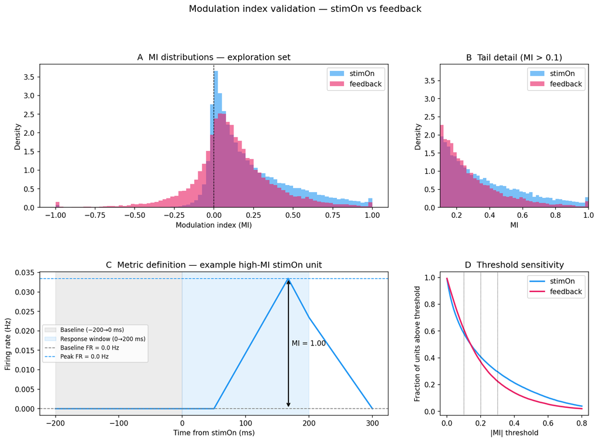

**Figure 1. Modulation index distributions and threshold sensitivity.** *Panel A*: Full MI distributions across all exploration-set units for stimOn (blue) and feedback (pink). Both are right-skewed, but feedback shows a heavier left tail (suppression). *Panel B*: Tail detail for MI > 0.1. *Panel C*: Metric definition on a representative high-MI stimOn unit, illustrating the baseline and peak response windows. *Panel D*: Fraction of units exceeding each |MI| threshold — the two events cross near MI ≈ 0.15, indicating that stimulus drives more units at *high* thresholds while feedback modulates more units overall at low thresholds.

### 3.3 Excited vs. suppressed units

A key finding from metric validation was that the two events differ not just in *how many* neurons they modulate, but in the *direction* of modulation.

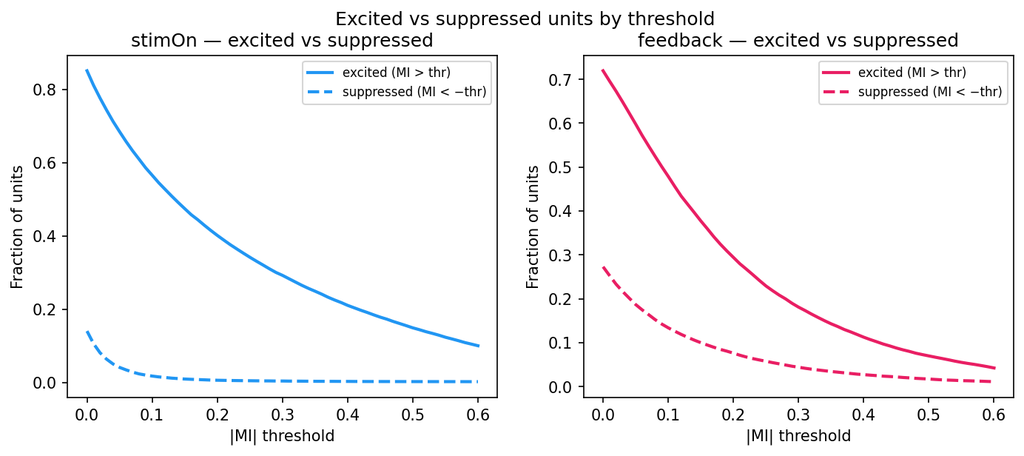

This finding led to three distinct, testable hypotheses:

- **H1 (Suppression asymmetry):** Feedback recruits more suppressed neurons per region than stimOn.
- **H2 (Excitation asymmetry):** StimulusOn recruits more excited neurons per region than feedback.
- **H3 (Total breadth):** Feedback modulates a greater fraction of neurons per region overall.

## 4 Locked Analysis Plan

### 4.1 Data

- Dataset: IBL Brain Wide Map, `bwm_ephys` v1.1.0.
- 75,395 good-quality units, 698 probe insertions, 266 Beryl-atlas regions, 12 laboratories.
- Events compared: `stimOn` vs. `feedback` (all trials pooled).
- Regions included: ≥ 10 good units present in both events (198 qualifying regions).

### 4.2 Data split

To prevent p-hacking, the dataset was split **before any analysis** into:

- **Exploration set:** 66 subjects (35,714 units, 248 regions), randomly selected with stratification by lab (seed = 42).
- **Confirmation set:** 73 subjects (39,681 units, 237 regions), held out until hypothesis lock.

### 4.3 Statistical tests (locked after exploratory analysis)

All three hypotheses were tested using the **Wilcoxon signed-rank test** on per-region paired differences (198 region pairs, one-sided, α = 0.05):

| Hypothesis | Comparison |
| --- | --- |
| H1 | feedback `frac_suppressed` > stimOn `frac_suppressed` |
| H2 | stimOn `frac_excited` > feedback `frac_excited` |
| H3 | feedback `frac_modulated` > stimOn `frac_modulated` |

## 5 Exploratory Results

### 5.1 Per-region responsive fractions

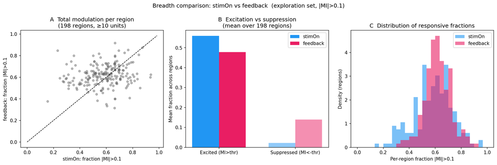

**Figure 3. Brain-wide breadth comparison (exploration set).** *Panel A*: Scatter of per-region total modulation fraction (|MI|>0.1) for each event. Points above the diagonal indicate regions more modulated by feedback. Feedback wins in most regions. *Panel B*: Mean excitation and suppression fractions across regions — stimOn (blue) excites more, feedback (pink) suppresses far more. *Panel C*: Distribution of per-region responsive fractions — the feedback distribution is shifted rightward, indicating more regions with higher fractions of modulated units.

At |MI| > 0.1, across 198 qualifying regions:

| Metric | stimOn | feedback |
| --- | --- | --- |
| Mean fraction modulated | 0.581 | 0.617 |
| Mean fraction excited | 0.559 | 0.478 |
| Mean fraction suppressed | 0.022 | 0.139 |
| Regions with >50% modulated | 144 | 174 |

### 5.2 Brain maps

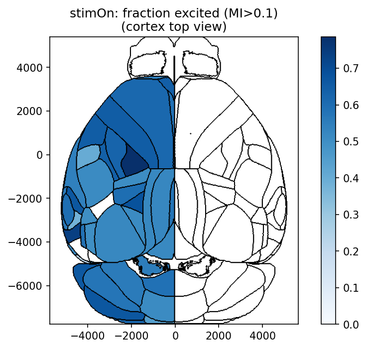

**Figure 4. Brain map — stimOn excited fraction (top view).** Fraction of neurons excited by stimulus onset per Beryl region, shown on the dorsal cortical surface. Thalamic nuclei and primary sensory areas show the highest excited fractions.

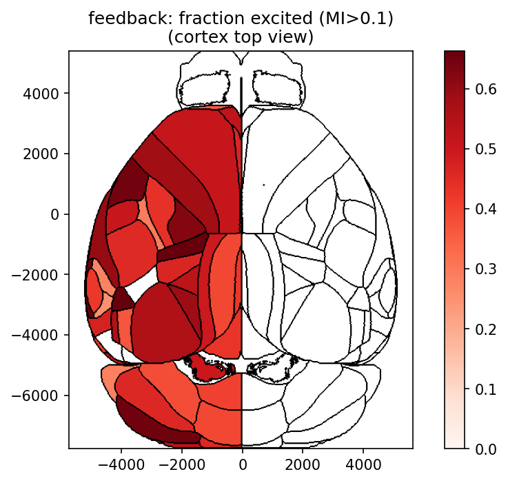

**Figure 5. Brain map — feedback excited fraction (top view).** Fraction of neurons excited by feedback per region. The spatial pattern differs substantially from stimulus: association and motor areas, thalamic nuclei (VPM, PCN, VAL), and cerebellar regions show high excited fractions.

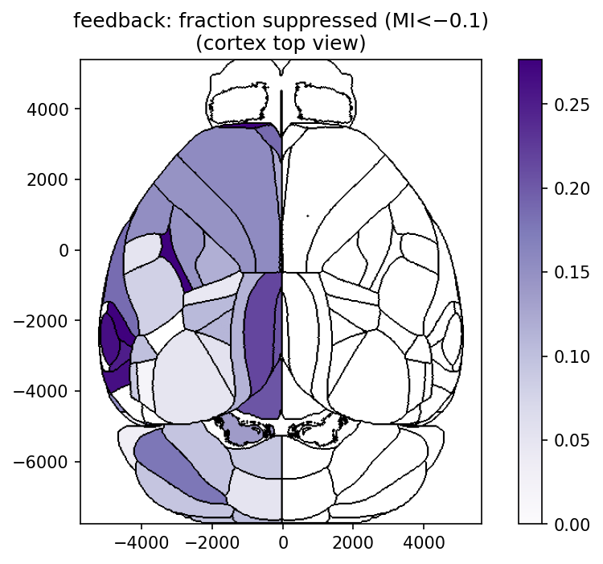

**Figure 6. Brain map — feedback suppressed fraction (top view).** Fraction of neurons suppressed by feedback (MI < −0.1) per region. This pattern has no counterpart in the stimulus map. Brainstem nuclei (XII, LRN, GRN, SPVI, MDRN), the thalamic reticular nucleus (TRN), and the dorsal raphe (DR) show the largest suppressed fractions.

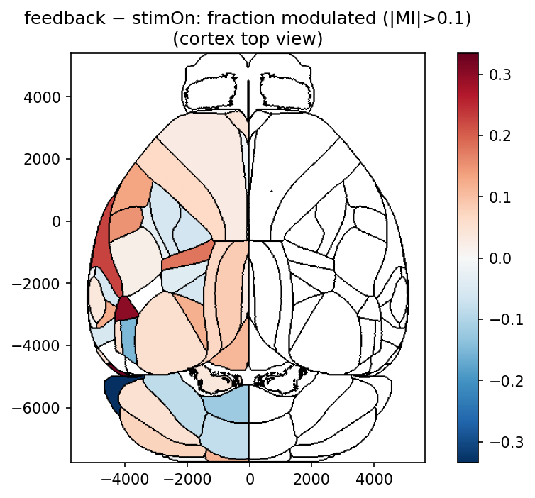

**Figure 7. Brain map — feedback minus stimOn modulation difference (top view).** Regions in red are more broadly modulated by feedback than by stimulus. Limbic, neuromodulatory, and brainstem regions show the largest excess feedback modulation. Blue regions (fewer) are more modulated by stimulus.

### 5.3 Notable regions

**Regions most strongly recruited by stimulus (stimOn excited fraction):** medial habenula (MH, 93%), nucleus incertus (NI, 88%), claustrum (CL, 86%), anterior ventral nucleus (AV, 84%), ventral posterolateral thalamus (VPL, 81%).

**Regions with largest feedback excess over stimulus:** dorsal raphe (DR, +62%), triangular septal nucleus (TTd, +45%), medial septal nucleus (MS, +42%), lateral preoptic area (LPO, +41%), visceral cortex (VISC, +35%).

## 6 Confirmatory Results

All three hypotheses were confirmed on the held-out 73-subject confirmation set (198 paired regions, Wilcoxon signed-rank, one-sided, α = 0.05):

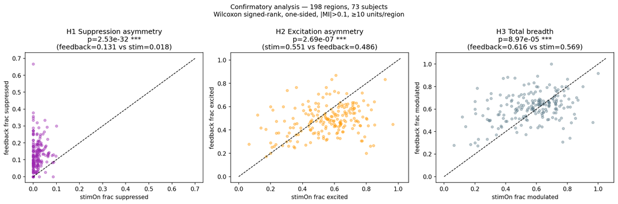

**Figure 8. Confirmatory analysis — paired region scatter plots.** Each point is one brain region. *Left (H1)*: feedback suppresses more neurons than stimOn in virtually every region (p = 2.5×10⁻³²). *Centre (H2)*: stimOn excites more neurons than feedback in the majority of regions (p = 2.7×10⁻⁷). *Right (H3)*: feedback has higher total modulation in the majority of regions (p = 9.0×10⁻⁵). All diagonal unity lines show the systematic skew of points above (H1, H3) or below (H2) parity.

| Hypothesis | Description | Mean (stimOn) | Mean (feedback) | p-value | Significance |
| --- | --- | --- | --- | --- | --- |
| **H1** | frac_suppressed: feedback > stimOn | 0.018 | 0.131 | 2.5 × 10⁻³² | *** |
| **H2** | frac_excited: stimOn > feedback | 0.551 | 0.486 | 2.7 × 10⁻⁷ | *** |
| **H3** | frac_modulated: feedback > stimOn | 0.569 | 0.616 | 9.0 × 10⁻⁵ | *** |

## 7 Discussion

### 7.1 Summary

Across 198 brain regions and 73 held-out mice, we find that feedback signals are both *more widespread* and *qualitatively different in character* compared to visual stimulus signals. The most striking distinction is not breadth but directionality: stimulus onset drives nearly pure excitation (55% of neurons excited, 2% suppressed), while feedback drives a substantial suppression component (49% excited, 13% suppressed) that is visible throughout the brain.

### 7.2 Relation to prior work

The widespread distribution of outcome signals is consistent with the view that the brain broadcasts feedback information broadly to update representations across many circuits (Schultz et al. 1997; Rangel et al. 2008). The dominance of *suppression* in feedback responses — particularly in the brainstem, reticular nucleus, and neuromodulatory regions — is less commonly highlighted and may reflect inhibitory gating of irrelevant sensory or motor processing during outcome evaluation.

The strong feedback modulation of the **dorsal raphe** (+62% excess over stimulus) is consistent with the established role of serotonergic neurons in encoding outcomes and waiting costs (Nakamura 2008; Liu et al. 2014). The **thalamic reticular nucleus (TRN)** suppression is also consistent with its role in gating thalamocortical transmission — outcome signals may suppress sensory relay to redirect processing toward outcome evaluation networks.

The high feedback modulation in the **medial septum** and **triangular septal nucleus** (TTd) is consistent with hippocampal-septal circuits processing spatial and temporal context around reward delivery.

### 7.3 Caveats

1. **Pooled feedback:** All feedback trials (correct and incorrect) are pooled in the stored features. Reward and error signals may have distinct spatial signatures; this should be examined in follow-up work using spike-level recomputation.
2. **Modulation index as a proxy:** The stored MI uses the peak of the smoothed PSTH in a 0–200 ms window. Units with slow-onset responses (>200 ms) may be misclassified as unmodulated. The MI is also symmetric with respect to the sign of rate change only through the absolute-value threshold; different shapes (e.g. transient excitation followed by suppression) can yield the same scalar.
3. **Threshold choice:** Results were stable across |MI| thresholds from 0.05 to 0.30, but the relative ranking of feedback vs. stimOn total breadth (H3) reverses at thresholds above ~0.15. The asymmetric suppression finding (H1) is robust across all thresholds tested.
4. **Statistical unit:** The Wilcoxon test treats brain regions as exchangeable units. Regions vary substantially in unit count (10 to 566), and results from small-*n* regions should be interpreted cautiously.
5. **Confounds:** Stimulus and feedback are separated in time within trials but may co-occur with movement and decision signals. The stored MI does not control for trial-type identity; a formal comparison would require GLM-based analyses.

### 7.4 Lessons for future AI-assisted analyses

- The most scientifically interesting finding (suppression asymmetry) was not part of the original question and emerged from the metric validation step. Plotting excited vs. suppressed separately — rather than only |MI| — is a productive early diagnostic for any modulation comparison and should be added as a default step.
- The stored `event_response_features` are sufficient for broad brain-wide screening questions, but separate reward/error analysis requires spike-level recomputation. The agent should recommend this follow-up explicitly when pooled feedback is used.

## 8 Suggested Instruction File Updates

The following suggestions are proposed for improving future agent performance. No files have been edited; these are suggestions for user review.

### 8.1 Addition to `skills/ibl-analyze/references/bwm_analysis_patterns.md`

> **Modulation direction diagnostic (default for any event-response comparison)** When comparing neural modulation across events or conditions, always plot excited and suppressed fractions separately before reporting total |MI| breadth. Suppression asymmetries can be the dominant signal but are invisible in total-modulation summaries.

### 8.2 Addition to `skills/ibl-analyze/references/scientific_context_and_metric_semantics.md`

> **Feedback pooling note:** The stored `event_response_features` feedback rows pool correct and incorrect trials. For analyses where reward vs. error distinction is scientifically relevant, flag this as a proxy and plan spike-level recomputation stratified by `feedbackType` from the trials table.

## 9 Methods

**Data:** IBL Brain Wide Map, `bwm_ephys` v1.1.0. 75,395 good-quality neurons from 698 Neuropixels probe insertions, 139 mice, 12 laboratories.

**Modulation index:** Precomputed stored feature. MI = (peak_FR − baseline_FR) / (peak_FR + baseline_FR). Baseline: −200 to 0 ms; peak window: 0–200 ms post-event; 5 ms bins, 20 ms Gaussian smoothing; all trials pooled per event.

**Threshold:** |MI| > 0.1. Units with MI > 0.1 classified as excited; MI < −0.1 as suppressed. Regions with < 10 good units excluded (198 of 266 Beryl regions retained).

**Data split:** 66 subjects for exploration (stratified by lab, seed = 42), 73 for confirmation. All confirmatory tests run exactly once on the held-out set.

**Statistics:** Wilcoxon signed-rank test on per-region paired differences (198 pairs), one-sided, α = 0.05. No multiple-comparison correction applied across the three pre-specified hypotheses.

**Atlas:** Beryl mapping (IBL atlas). Brain maps generated with `iblatlas.plots.plot_scalar_on_slice`.

**Software:** Python 3.14, `ibllib`, `iblatlas`, `one-api`, `scipy`, `pandas`, `matplotlib`, `ibl-ai-agent` v0.1.0.

## References

International Brain Laboratory. 2025. “A Brain-Wide Map of Neural Activity During Complex Behaviour.” *Nature*, ahead of print. https://doi.org/10.1038/s41586-025-09235-0.

Liu, Zhixiang, Jingfeng Zhou, Yi Li, et al. 2014. “Dorsal Raphe Neurons Signal Reward Through 5-HT and Glutamate.” *Neuron* 81 (6): 1360–74.

Musall, Simon, Matthew T Kaufman, Ashley L Juavinett, Steven Gluf, and Anne K Churchland. 2019. “Single-Trial Neural Dynamics Are Dominated by Richly Varied Movements.” *Nature Neuroscience* 22 (10): 1677–86.

Nakamura, Kae. 2008. “The Dorsal Raphe Nucleus Integrates Cortical and Subcortical Inputs.” *Frontiers in Integrative Neuroscience* 2: 1.

Rangel, Antonio, Colin Camerer, and P Read Montague. 2008. “A Framework for Studying the Neurobiology of Value-Based Decision Making.” *Nature Reviews Neuroscience* 9 (7): 545–56.

Schultz, Wolfram, Peter Dayan, and P Read Montague. 1997. “A Neural Substrate of Prediction and Reward.” *Science* 275 (5306): 1593–99.

Steinmetz, Nicholas A, Cagatay Aydin, Anna Lebedeva, et al. 2021. “Neuropixels 2.0: A Miniaturized High-Density Probe for Stable, Long-Term Brain Recordings.” *Science* 372 (6539).

Stringer, Carsen, Marius Pachitariu, Nicholas Steinmetz, Matteo Carandini, and Kenneth D Harris. 2019. “Spontaneous Behaviors Drive Multidimensional, Brainwide Activity.” *Science* 364 (6437).